# RALLF Forage Quality

preliminary report

Jesse Puka-Beals

2023 April

### To do

Validate the predicted forage quality parameters with wet chemistry. When we predicted NDFD for IWG in FIG the values were reasonable (50%), but for alfalfa they are unreasonable (16%). For example, Grev et al. (2017) observed NDFD range of 33-45% for a 30 day cutting interval.

Investigate the 3rd cut in st paul 2022.

### Expected results

Alfalfa varieties (HarvXtra) will have lower lignin content and higher NDFD than conventional varieties. The RFV should be higher for HarvXtra varieties.

Alfalfa with lower intervals between cuttings (35-day vs 45-day ) will have higher forage quality (RFV, CP).

### Discussion topics

#### RFV vs. RFQ

If we are only making comparisons among alfalfa cuttings, let’s use RFV not RFQ. RFQ relies on NDFD, which is much harder to predict with NIRS. There is lot of variability in NDFD in wet chemsity due to variability in rumen fluid composition from donor cows, this variability extends into the NIRS database for NDFD, which reduces the accuracy of the NIRS predictions. RFQ is useful when comparing between mixtures of legumes and grasses, but since we are only making comparisons between alfalfa cuttings, RFV allows us to rely on just ADF and NDF, which NIRS performs better at predicting.

#### NIRS prediction

Do we trust the predicted values of the NIRS for this experiment?

Is the hay equation sufficient for making comparisons between HarvXtra vs. conventional alfalfa forage quality?

Why is the RFV prediction so high for alfalfa?

Why is neutral detergent digestibility so low? We need to be skeptical of RFQ so long as we are skeptical of NDFD.

Why is variance so low in the NIRS prediction?

### Data availability

[*https://github.com/jpukabeals/rallf*](https://github.com/jpukabeals/rallf)

# Data we have

NIRS data

| year | site | intensity | cut | n | n_missing |
| --- | --- | --- | --- | --- | --- |
| 2021 | st paul | 35-day | 1 | 24 | 0 |
| 2022 | st paul | 35-day | 1 | 24 | 0 |
| 2021 | rosemount | 35-day | 1 | 24 | 0 |
| 2022 | rosemount | 35-day | 1 | 24 | 0 |
| 2021 | st paul | 45-day | 1 | 24 | 0 |
| 2022 | st paul | 45-day | 1 | 24 | 0 |
| 2021 | rosemount | 45-day | 1 | 24 | 0 |
| 2022 | rosemount | 45-day | 1 | 24 | 0 |
| 2021 | st paul | 35-day | 2 | 24 | 0 |
| 2022 | st paul | 35-day | 2 | 24 | 0 |
| 2021 | rosemount | 35-day | 2 | 24 | 0 |
| 2022 | rosemount | 35-day | 2 | 24 | 0 |
| 2021 | st paul | 45-day | 2 | 23 | 1 |
| 2022 | st paul | 45-day | 2 | 24 | 0 |
| 2021 | rosemount | 45-day | 2 | 24 | 0 |
| 2022 | rosemount | 45-day | 2 | 24 | 0 |
| 2021 | st paul | 35-day | 3 | 24 | 0 |
| 2022 | st paul | 35-day | 3 | 24 | 0 |
| 2021 | rosemount | 35-day | 3 | 24 | 0 |
| 2022 | rosemount | 35-day | 3 | 24 | 0 |
| 2022 | st paul | 45-day | 3 | 24 | 0 |
| 2022 | rosemount | 45-day | 3 | 24 | 0 |
| 2022 | st paul | 35-day | 4 | 24 | 0 |
| 2022 | rosemount | 35-day | 4 | 24 | 0 |

NIRS data

| year | site | intensity | cut | n | n_missing |
| --- | --- | --- | --- | --- | --- |
| 2021 | st paul | 45-day | 2 | 23 | 1 |

As seen in tables, we have 1 missing data point

# Predicting forage quality parameters with NIRS

We are predicting alfalfa forage quality parameters using near infrared scanning with a generalist equation designed for all hay. Some labs use an alfalfa equation and some labs have different alfalfa equations for conventional vs. reduced lignin alfalfa. All predictions should be validated with wet chemistry. NIRS predictions without recent validation can still be useful in estimating relative differences between treatments.

Soil contamination can cause issues with forage quality predictions.

Expected forage quality parameters for alfalfa were easy to obtain for CP ADF NDF and RFV, they were not easy to obtain for RFQ. In general, I found that RFQ can range from 50 to 250, with most data between 100 and 200 and an average of 150.

Expected forage quality ranges from Dairyland Labs

| Parameter | Median | Range |
| --- | --- | --- |
| CP | 20 | 14-26 |
| ADF | 31 | 20-43 |
| NDF | 38 | 35-52 |
| Lignin | 6 | 4-8 |

Expected forage quality ranges from UMN, SDSU, Univeristy of Georgia and Dairyland

| Maturity | Stage | Grade | CP | ADF | NDF | RFV | RFQ |
| --- | --- | --- | --- | --- | --- | --- | --- |
| all | all |  | 14-26 | 20-43 | 25-56 | 92-200 | 80-260 |
| early maturity | bud | premium | 20-22 | 27-29 | 34-36 | 170-185 | 180-220 |
| early to average maturity | early bloom | good | 18-20 | 29-32 | 36-40 | 150-170 | 140-180 |
| late maturity | full bloom | fair | 16-18 | 32-35 | 40-44 | 130-150 | 80-140 |

Observed vs. expected forage quality in RALLF

| Forage Quality Parameter | Observed | Expected | Expected Range |
| --- | --- | --- | --- |
| CP | 21 | 20 | 14-26 |
| ADF | 23 | 30 | 20-43 |
| NDF | 33 | 40 | 25-56 |
| NDFD | 15 | 50 | 40-60 |
| RFV | 211 | 150 | 92-200 |
| RFQ | 142 | 150 | 80-260 |

Forage quality parameters reported by Grev 2017 on alfalfa stands in St Paul and Rosemount planted in spring and cut on 30 day harvest intervals over two years. Mean and (range) are presented.

| Type | CP | NDF | NDFD |
| --- | --- | --- | --- |
| Conventional | 20 (18-23) | 39 (35-43) | 36 (30-44) |
| Reduced Lignin | 21 (18-23) | 38 (35-42) | 39 (33-45) |

Forage quality comparison between Grev et al 2017 and RALLF

| source | Type | CP | NDF | NDFD |
| --- | --- | --- | --- | --- |
| Observed | Conventional | 21 | 33 | 16 |
| Observed | Reduced Lignin | 21 | 33 | 15 |
| Grev et al. 2017 | Conventional | 20 | 39 | 36 |
| Grev et al. 2017 | Reduced Lignin | 21 | 38 | 39 |

# Summary tables

Forage quality by rep

| Rep | CP | ADF | NDF | NDFD | RFV | RFQ |
| --- | --- | --- | --- | --- | --- | --- |
| 1 | 20 | 24 | 33 | 16 | 206 | 138 |
| 2 | 21 | 23 | 32 | 15 | 213 | 144 |
| 3 | 21 | 23 | 33 | 15 | 212 | 143 |
| 4 | 21 | 23 | 32 | 15 | 213 | 144 |

Forage quality by site

| Site | CP | ADF | NDF | NDFD | RFV | RFQ |
| --- | --- | --- | --- | --- | --- | --- |
| rosemount | 21 | 24 | 34 | 17 | 201 | 135 |
| st paul | 21 | 23 | 31 | 14 | 222 | 150 |

Forage quality by year

| Year | CP | ADF | NDF | NDFD | RFV | RFQ |
| --- | --- | --- | --- | --- | --- | --- |
| 2021 | 21 | 22 | 32 | 14 | 215 | 141 |
| 2022 | 21 | 24 | 33 | 17 | 209 | 143 |

Forage quality by cutting

| Cut | CP | ADF | NDF | NDFD | RFV | RFQ |
| --- | --- | --- | --- | --- | --- | --- |
| 1 | 22 | 20 | 28 | 10 | 248 | 160 |
| 2 | 21 | 26 | 36 | 19 | 186 | 129 |
| 3 | 20 | 24 | 33 | 17 | 207 | 144 |
| 4 | 20 | 27 | 37 | 19 | 175 | 120 |

Forage quality by harvest schedule

| Intensity | CP | ADF | NDF | NDFD | RFV | RFQ |
| --- | --- | --- | --- | --- | --- | --- |
| 35-day | 21 | 23 | 32 | 15 | 214 | 146 |
| 45-day | 20 | 24 | 34 | 16 | 207 | 137 |

Forage quality by variety

| Variety | CP | ADF | NDF | NDFD | RFV | RFQ |
| --- | --- | --- | --- | --- | --- | --- |
| HX3 | 21 | 22 | 32 | 14 | 220 | 146 |
| HX4 | 21 | 23 | 33 | 15 | 209 | 139 |
| HX5 | 20 | 24 | 33 | 15 | 206 | 136 |
| RR3 | 21 | 23 | 32 | 16 | 214 | 147 |
| RR4 | 21 | 24 | 33 | 17 | 209 | 144 |
| RR5 | 21 | 24 | 33 | 16 | 209 | 142 |

# Histograms

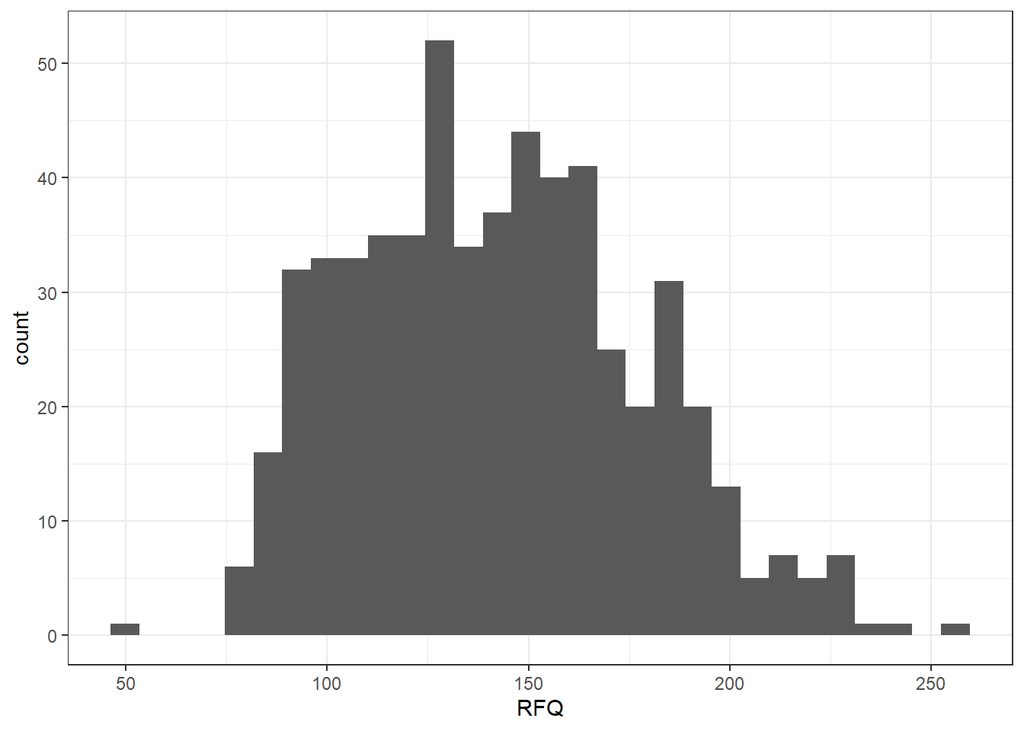

We expect an RFQ of around 150, we observed an RFQ of 142

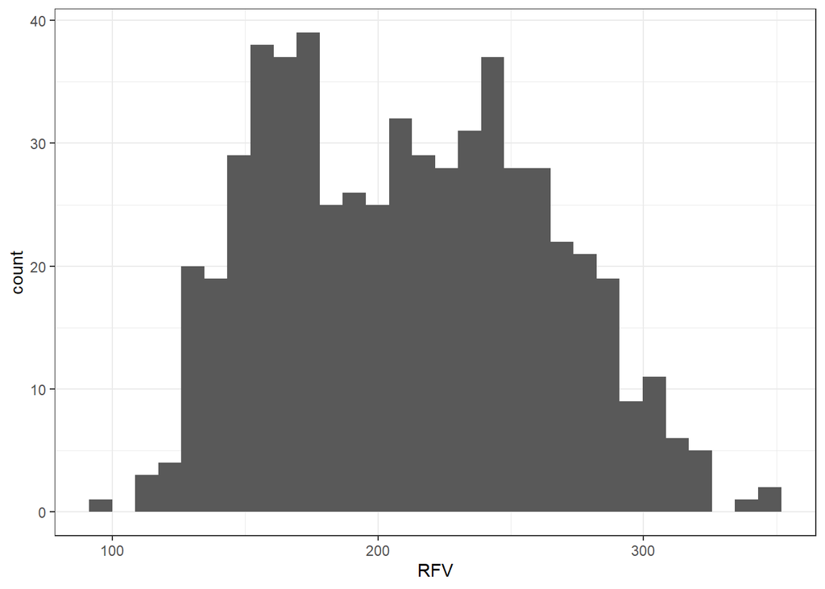

We expect an RFV of around 150, we observed an RFV of 211. Some samples were predicted to have an RFV greater than 300!

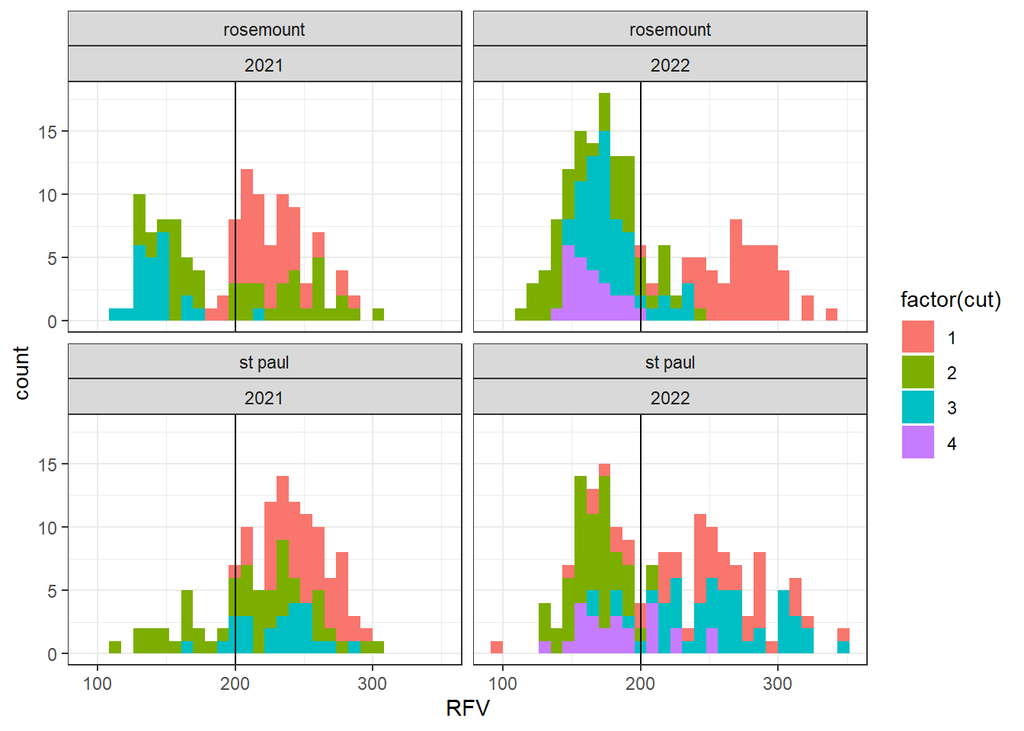

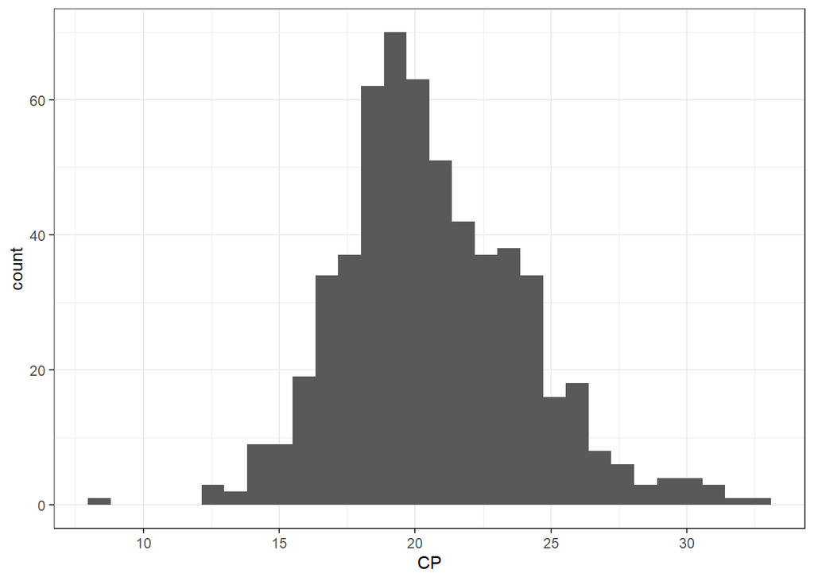

We expect a crude protein of around 20%, we observed a CP of 21

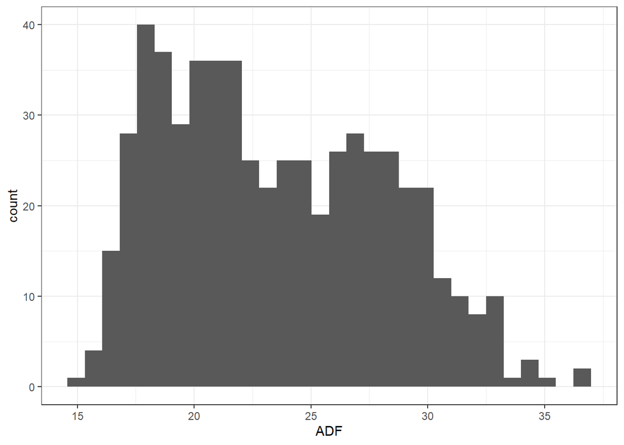

We expect an ADF of around 30%, we observed an ADF of 23

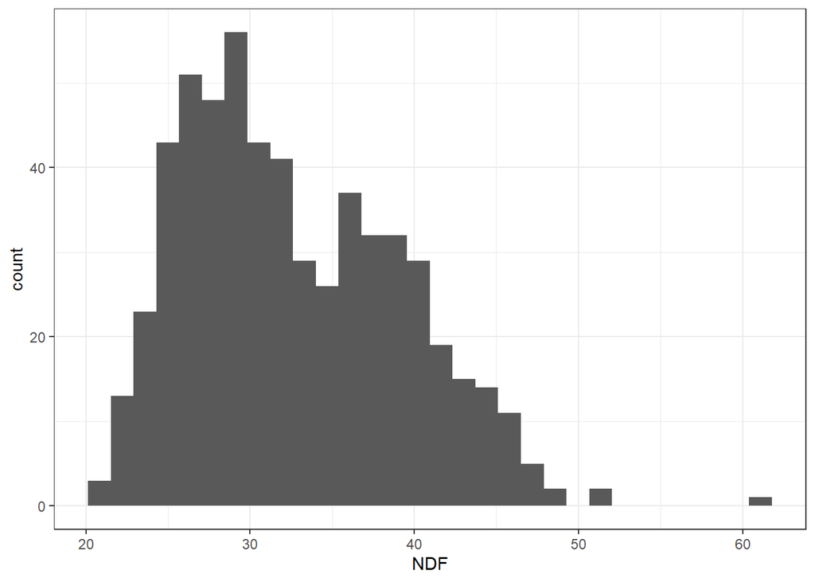

We expect an NDF of around 40%, we observed an NDF of 33

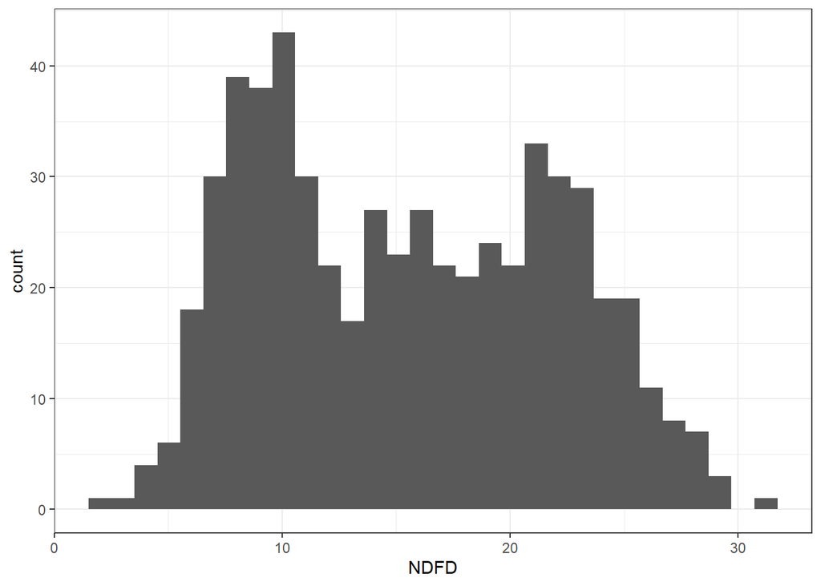

For neutral detergent digestibility over 48 hours, we expect values near 50%, we predicted values of 15

# Analysis

## Relative feed value

Since relative feed value and relative forage quality are strongly correlated, the results of the analysis tend to be the same.

```r
dat1 %>%
  lm(
    rfv~site*year*variety*intensity*cut,.
  ) %>%
  anova() %>%
  filter(`Pr(>F)` < 0.05)
```

```
Analysis of Variance Table

Response: rfv
                        Df Sum Sq Mean Sq  F value    Pr(>F)
site                     1  60659   60659  37.2124 2.186e-09 ***
intensity                1   6650    6650   4.0795  0.043963 *
cut                      1 277484  277484 170.2280 < 2.2e-16 ***
year:intensity           1   8773    8773   5.3818  0.020767 *
site:cut                 1 122131  122131  74.9236 < 2.2e-16 ***
year:cut                 1  12809   12809   7.8582  0.005264 **
site:year:intensity      1  13655   13655   8.3768  0.003974 **
site:intensity:cut       1  26035   26035  15.9716 7.443e-05 ***
year:intensity:cut       1  52212   52212  32.0304 2.617e-08 ***
site:year:intensity:cut  1  37232   37232  22.8406 2.345e-06 ***
---
Signif. codes:  0 '***' 0.001 '**' 0.01 '*' 0.05 '.' 0.1 ' ' 1
```

```r
# year:intensity:cut
# site:year:cut
# site:year:intensity

# no effect from variety
```

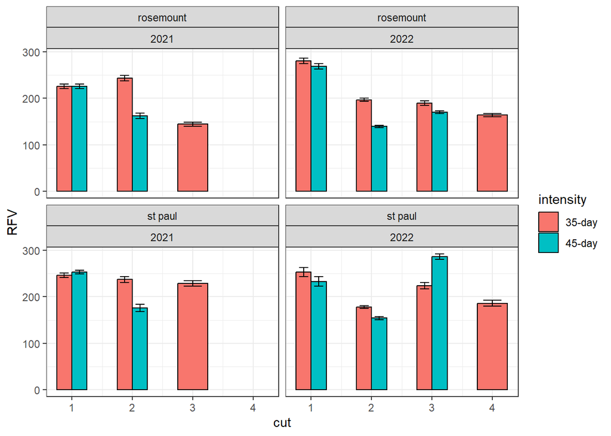

Similar pattern across years and sites; RFV is similar for the first cut and then the second cut the RFV is lower for the 45-day cuts than the 35-day cuts. The third cut at St Paul in 2022 is unexpected, what could explain this?

Why is variance so low? Standard error bars are barely visible.

Let’s look at standard deviation instead of standard error

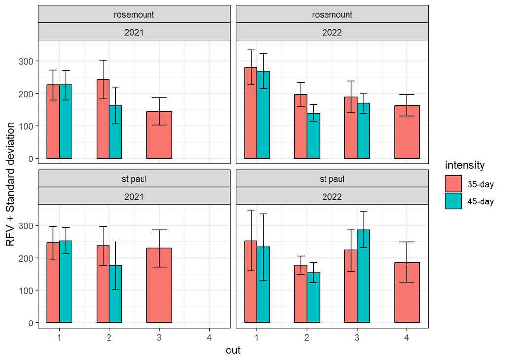

There is simply a large difference between standard error and standard deviation, likely because n() is larger than usual (n=24) so standard error really reduces the visual representation of variance.

## Crude protein

```r
dat1 %>%
  lm(
    CP~site*year*variety*intensity*cut,.
  ) %>%
  anova() %>%
  filter(`Pr(>F)` < 0.05)
```

```
Analysis of Variance Table

Response: CP
                        Df Sum Sq Mean Sq F value    Pr(>F)
intensity                1  98.96   98.96  9.3565  0.002346 **
cut                      1 349.74  349.74 33.0677 1.588e-08 ***
year:intensity           1 105.97  105.97 10.0197  0.001647 **
site:cut                 1 177.82  177.82 16.8130 4.846e-05 ***
intensity:cut            1  55.15   55.15  5.2145  0.022836 *
site:year:intensity      1  72.84   72.84  6.8868  0.008961 **
site:intensity:cut       1  70.86   70.86  6.6994  0.009937 **
site:year:intensity:cut  1 325.18  325.18 30.7453 4.870e-08 ***
---
Signif. codes:  0 '***' 0.001 '**' 0.01 '*' 0.05 '.' 0.1 ' ' 1
```

```r
# 4-way interaction

# no effect from variety
```

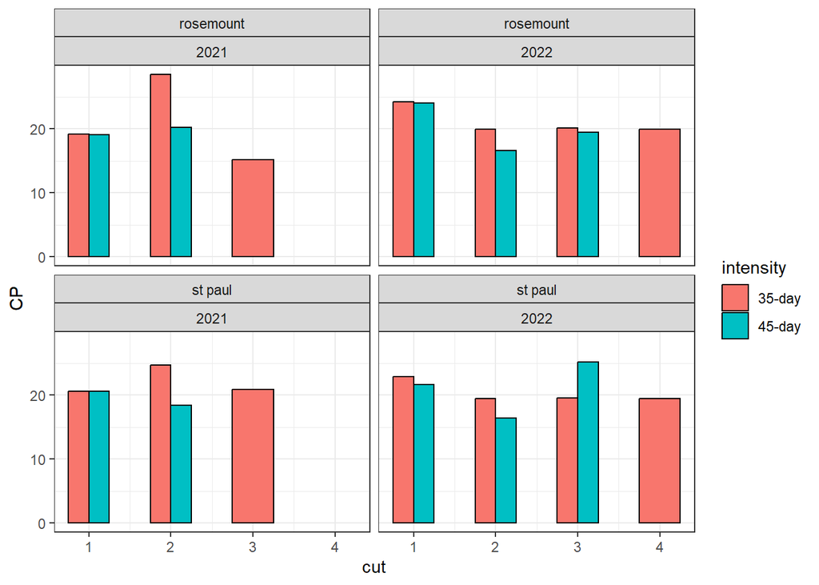

Similar pattern across years and sites, same as RFQ; CP is similar for the first cut and then the second cut the CP is lower for the 45-day cuts than the 35-day cuts.

Same as with RFQ, summarizing with standard error shows much less variation around means than standard deviation.

# Diving deeper

## Relative feed value and ADF

This may be due to an issue with the equation

Let’s look at the RFV equation I used

```
function (nir_tidy_data)
{
    nir_tidy_data %>% mutate(DM = drymatter, CP = protein, NDF = ndf,
        NDFD = ndf48h, ADF = adf, EE = 2.05, FA = EE - 1, Ash = 100 -
            DM, NFC = 100 - ((0.93 * NDF) + CP + EE + Ash), NDFn = NDF *
            0.93, NDFDp = 22.7 + 0.664 * NDFD, TDN.legume = (NFC *
            0.98) + (CP * 0.93) + (FA * 0.97 * 2.25) + (NDFn *
            NDFD/100) - 7, DMI.legume = (120/NDF) + (NDFD - 45) *
            0.374/1350 * 100, rfq.legume = DMI.legume * TDN.legume/1.23,
        DDM.rfv = 88.9 - (0.779 * ADF), DMI.rfv = 120/NDF, rfv.sdsu = DDM.rfv *
            DMI.rfv/1.29)
}
```

So I used …

Digestible dry matter  
$DDM.rfv = 88.9-(0.779*ADF)$

Dry matter intake  
$DMI.rfv = 120/NDF$

Relative Forage Value  
$RFV = (88.9-(0.779*ADF))*(120/NDF)/1.29$

These equations are correct.

Let’s look at the samples with the highest RFV values

The samples with the highest estiamted relative feed value

| site | year | intensity | cut | variety | rep | CP | ADF | NDF | NDFD | rfv | rfq.legume |
| --- | --- | --- | --- | --- | --- | --- | --- | --- | --- | --- | --- |
| st paul | 2022 | 45-day | 3 | RR5 | 2 | 29 | 16 | 20 | 5 | 350 | 253 |
| st paul | 2022 | 35-day | 1 | HX3 | 2 | 24 | 16 | 21 | 6 | 343 | 241 |
| rosemount | 2022 | 35-day | 1 | HX4 | 1 | 26 | 16 | 21 | 2 | 341 | 227 |
| st paul | 2022 | 45-day | 3 | RR4 | 4 | 27 | 18 | 22 | 8 | 322 | 235 |
| st paul | 2022 | 45-day | 1 | HX5 | 2 | 23 | 16 | 22 | 9 | 320 | 218 |

The forage samples with the highest RFV are from st paul in 2022. The ADF is 16% and the NDF is 20%. A forage sample with these values would have a relative feed value of 355, so the equation is not incorrect. The question is whether alfalfa can be this high quality.

Can an alfalfa sample be 16% ADF and 20% NDF?

It’s notable that the crude protein is also very high, 29%, where we would normally expect 20%. This supports the idea that this was young vegetative leafy alfalfa.

It seems very possible that our predicted ADF and NDF values simply need a bias adjustment. If this is the case, they can still be used to determine relative differences between treatments, but will need a wet chemistry calibration before they can be used to determine the actual ADF or NDF values.

## NDFD

Neutral detergent fiber digestibility estimates the amount of digestion that will occur within the rumen and this varies by ruminant. The most common durations are 24 hours for cattle, 30 hours for sheep goats and horses, 48 hours for swine. There are also very long digestions (72, 120 or 240), which are meant to determine how much fiber is indigestible.

We predict neutral detergent fiber digestibility over 48 hours because this is used for the RFQ equation (Undersander and Moore, 2002). We expect an NDFD range of 30-50% for alfalfa based on data from Dairyland and Forage Genetics International, but NDFD can range up to 70%(Hoffman et al., 2001).

Expected lignin and NDFD values of different varieties and harvest schedules

| Variety | Intensity | Lignin (%) | NDFD (%) |
| --- | --- | --- | --- |
| HarvXtra | 45-day | 5.0 | 40 |
| HarvXtra | 35-day | 4.5 | 49 |
| Conventional | 45-day | 6.5 | 35 |
| Conventional | 35-day | 5.7 | 43 |

Predicted NDFD values did not match with expected values

| Variety | Intensity | NDFD_expected | NDFD_observed |
| --- | --- | --- | --- |
| HarvXtra | 45-day | 40 | 15.1 |
| HarvXtra | 35-day | 49 | 14.4 |
| Conventional | 45-day | 35 | 16.2 |
| Conventional | 35-day | 43 | 16.4 |

We observed around 15% NDFD, which very low.

We expected greater NDFD in HarvXtra vs conventional, but observed lower NDFD.

One possible explanation is that our NDFD prediction needs a new equation for alfalfa NDFD as it differs from grass NDFD.

Another explanation is that we need a different equation for HarvXtra alfalfa vs. conventional alfalfa.

The predicted NIRS values for NDFD should be viewed with skepticism, and it likely cannot be fixed with a bias.

| max(NDFD) | min(NDFD) | median(NDFD) |
| --- | --- | --- |
| 32 | 2 | 15 |

Does the low NDFD values make the RFQ values lower, causing the RFQ and RFV to not be well correlated?

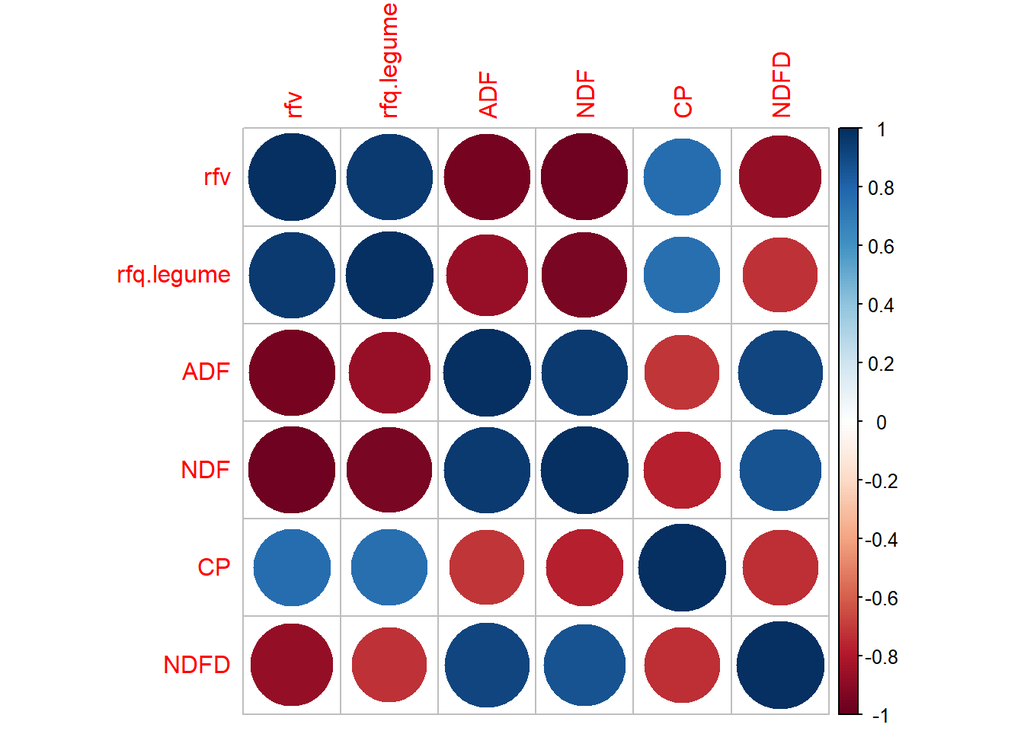

Yes, RFV and RFQ are strongly positively correlated as they should be.

Other forage quality parameters are correlated as expected with the exception of NDFD.

As forages mature, CP should decrease and NDFD should decrease, therefore they should be positively correlated, but instead they are negatively correlated. Furthermore, as NDFD increases RFQ should increase, but they are also negatively correlated.

## RFQ

RFQ should be positively correlated with RFV and have a close relationship (slope near 1)

$$RFQ = 1.2*RFV - 32.4$$
(Undersander and Moore, 2002)

[output not shown]

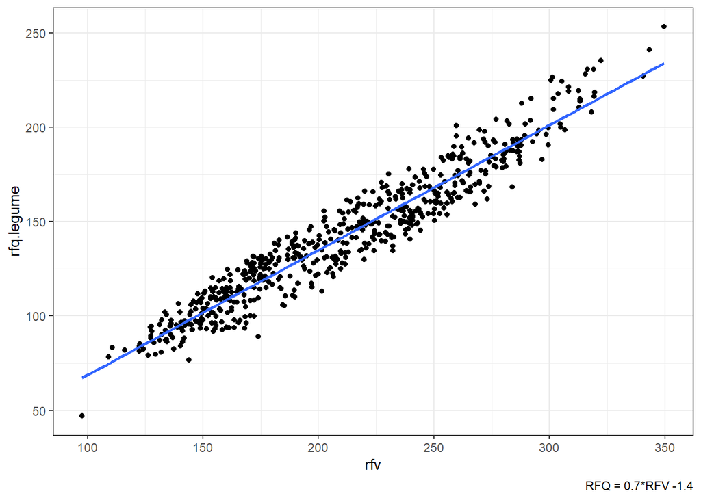

This indicates there is an issue with how we are estimating some of the forage quality parameters that comprise RFV and RFQ

#### NDFD underestimation

With an RFV of 187, we would expect an RFQ of 192 and we predict 200. Much better! By multiplying NDFD by 3.125, we are still not fixing the issue of NDFD not being positively correlated with CP, indicating a larger problem with it’s prediction. More importantly, the linear relationship is ever worse now at $RFQ = 0.34*RFV + 193$

At what NDFD value could we achieve the slope closest to 1.2*RFV while keeping the ADF and NDF adjustment?

We cannot achieve a slope of $RFQ = 1.2RFV$ by simply adjusting NDFD.

What would it take? It’s not clear but NDFD needs to be addressed. Simply multiplying NDFD is too crude and we likely need to improve our equation for NDFD prediction. Adjustments of ADF and NDF shift both RFQ and RFV, adjustments of CP and EE do not seem to change relationship greatly.

Another step that could be taken would be to note the mahalanoibis distances for NDFD prediction for RALLF. We would expect them to be above 5, indicating a warning.

#### Extractable ether

Extractable ether in our equation is set at 2.05 as a constant. But according to Undersander et al. (2016), extractable ether ranges from 1 to 4 and averages at 3 for alfalfa/grass forage.

Adjusting extractable ether does not have a large effect on predicted RFQ or RFV, so it doesn’t really matter. Just a heads up.

# References

Grev, A.M., M. Scott Wells, D.A. Samac, K.L. Martinson, and C.C. Sheaffer. 2017. Forage accumulation and nutritive value of reduced lignin and reference alfalfa cultivars. Agronomy Journal 109(6): 2749–2761. doi: 10.2134/agronj2017.04.0237.

Hoffman, P.C., R.D. Shaver, D.K. Combs, D.J. Undersander, L.M. Bauman, et al. 2001. Understanding NDF Digestibility of Forages. Focus on Forage 3(10): 3–5.

Undersander, D., D. Combs, and R. Shaver. 2016. Milk2016 ( ALFALFA-GRASS ): Index Combining Yield and Quality. University of Wisconsin-Extension 2016: 1–3. https://fyi.uwex.edu/forage/milk2016-combining-yield-and-quality-into-a-single-term/.

Undersander, D., and J.E. Moore. 2002. Relative forage quality. Focus on Forage 12(6): 1–3. http://www.foragelab.com/Media/Relative_Forage_Quality.pdf.